# Variable Renewable Energy (VRE) – Capacity factor prediction

We propose a modeling strategy to **predict monthly capacity factors** for:

- **solar photovoltaic power**,
- **onshore wind power**,

in different France regions, based on:

- capacity factor observations,
- climate variables from MERRA-2.

The objective is to build a supervised model that, for each region and each month, estimates the capacity factor based on monthly aggregated climate variables.

# Modeling strategy

## I. Feature analysis and selection

1. **Data loading**
   - Monthly capacity factors for wind and solar power by region (2014–2021).
   - Regional mask
   - MERRA-2 daily climate variables (2010–2019): surface radiation, temperature, air density, specific humidity, zonal and meridional winds.
2. **Pre-processing of climate variables**
   - Aggregation by region.
   - Aggregation by month.
   - Addition of variables reflecting intra-monthly behavior (quantiles, variance, etc.)
   - Encoding of regions
3. **Temporal separation of training/testing**
   - We simply propose to separate the dataset into two parts (2014-2018 for training and 2019 for testing).
   - We then normalize the training and testing sets.
4. **An initial “naive” regression**
   - We first perform a simple ordinary linear regression.
   - With the same input and output variables for solar and wind power:
     - Inputs: the 9 climate variables initially provided (and for each, their mean, variance, and quantiles q25, q50, and q75) + encoded regions
     - Output: monthly capacity factor.
5. **Evaluation**
   - Indicators: **MAE**, **RMSE**, **R²** on the test set.
   - Visualizations:
     - scatter plot *observed vs. predicted* on the test set,
     - time series on a selected region.
6. **Selection of relevant climate variables**
   - The purpose of this initial linear regression is to gain an understanding of the variables involved in solar and wind power regression.
   - We represent the share of each input variable in the model's ability to predict the capacity factor.
   - We also represent a covariance matrix to see if variables encapsulate the same phenomena.
   - Finally, we represent the covariance of each variable relative to the capacity factor.
   - Based on this information, we perform feature engineering to retain the most useful variables.

## II. Study for solar photovoltaics

1. **Study of an ordinary linear regression trained for solar energy**
   - We retrain an ordinary linear regression but only with the solar features selected in Part I.
   - We then evaluate the model with various indicators (**MAE**, **RMSE**, **R²**), on both the test set and the train set
   - Visualizations:
     - scatter plot *observed vs. predicted* on the test set,
     - time series on a selected region.
2. **Suspicion of overfitting**
   - We produce a learning curve to assess wether the model is overfitting or not
3. **A first regularisation technique : Ridge regression**
   - We optimize the hyperparameter alpha of the model
   - We plot the distribution of the model coefficients to assess the usefulness of the regularisation
   - Evaluation of the model
4. **A second regularisation technique : Lasso regression**
   - We optimize the hyperparameter alpha of the model
   - We plot the distribution of the model coefficients to assess the usefulness of the regularisation
   - Evaluation of the model
5. **Study of the data distribution**
   - We do a randomized train/test split
   - We train an OLS regression with a such split
   - Evaluation of the model
   - We represent the data distribution with a PCA

## I. Feature analysis and selection

1. **Data loading**

```python
import pandas as pd
import numpy as np
from pathlib import Path
import xarray as xr
import seaborn as sns

from sklearn.metrics import mean_absolute_error, mean_squared_error, r2_score
from sklearn.linear_model import LinearRegression

import matplotlib.pyplot as plt

from sklearn.ensemble import RandomForestRegressor
from sklearn.model_selection import cross_val_score, KFold, TimeSeriesSplit, learning_curve
from sklearn.model_selection import cross_val_predict
from sklearn import linear_model
from sklearn.linear_model import Ridge
from sklearn.linear_model import Lasso
```

```python
DATA_DIR = Path('data')

# Capacity factors :
df_pv = pd.read_csv(Path(DATA_DIR, 'reseaux_energies_capacityfactor_pv.csv'), index_col=0, parse_dates=True, header=0)
df_wind = pd.read_csv(Path(DATA_DIR, 'reseaux_energies_capacityfactor_wind-onshore.csv'), index_col=0, parse_dates=True, header=0)

print("PV capacity factor shape:", df_pv.shape)
print("Wind capacity factor shape:", df_wind.shape)

# Mask :
ds_mask = xr.load_dataset(Path(DATA_DIR, "mask_datagouv_french_regions_merra2_Nx_France.nc"))

mask_var_name = list(ds_mask.data_vars)[0]
mask = ds_mask[mask_var_name]


# Climate data :
h500 = xr.load_dataset(Path(DATA_DIR, "merra2_area_selection_output_height_500_merra2_2010-2019.nc"))

meri_wind = xr.load_dataset(Path(DATA_DIR, "merra2_area_selection_output_meridional_wind_merra2_2010-2019.nc"))
upper_meri_wind = xr.load_dataset(Path(DATA_DIR, "merra2_area_selection_output_upper_meridional_wind_merra2_2010-2019.nc"))
zonal_wind = xr.load_dataset(Path(DATA_DIR,"merra2_area_selection_output_zonal_wind_merra2_2010-2019.nc"))
upper_zonal_wind = xr.load_dataset(Path(DATA_DIR, "merra2_area_selection_output_upper_zonal_wind_merra2_2010-2019.nc"))

surf_density = xr.load_dataset(Path(DATA_DIR, "merra2_area_selection_output_surface_density_merra2_2010-2019.nc"))
surf_radiation = xr.load_dataset(Path(DATA_DIR, "merra2_area_selection_output_surface_downward_radiation_merra2_2010-2019.nc"))
surf_humidity = xr.load_dataset(Path(DATA_DIR, "merra2_area_selection_output_surface_specific_humidity_merra2_2010-2019.nc"))
surf_temperature = xr.load_dataset(Path(DATA_DIR, "merra2_area_selection_output_surface_temperature_merra2_2010-2019.nc"))

climate_datasets = [
    h500, meri_wind, upper_meri_wind, zonal_wind, upper_zonal_wind,
    surf_density, surf_radiation, surf_humidity, surf_temperature
]
ds_climate = xr.merge(climate_datasets)
```

```
PV capacity factor shape: (96, 12)
Wind capacity factor shape: (96, 12)
```

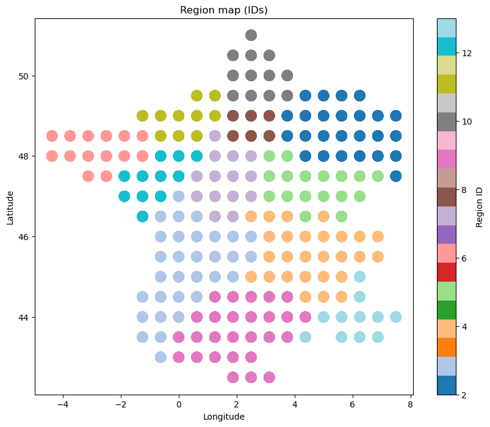

```python
# Regional mask visualization :

df_mask = ds_mask.to_dataframe().reset_index()
plt.figure(figsize=(10, 8))
plt.scatter(df_mask['lon'], df_mask['lat'], c=df_mask[mask_var_name], cmap='tab20', s=150)
plt.colorbar(label='Region ID')
plt.title("Region map (IDs)")
plt.xlabel("Longitude")
plt.ylabel("Latitude")
plt.show()

# We can deduce the mapping (ID -> Region Name) as follows:
region_mapping = {4: 'Auvergne-Rhône-Alpes'
                    , 5: 'Bourgogne-Franche-Comté'
                    , 6: 'Bretagne'
                    , 7: 'Centre-Val de Loire'
                    , 2: 'Grand Est'
                    , 10: 'Hauts-de-France'
                    , 11: 'Normandie'
                    , 3: 'Nouvelle-Aquitaine'
                    , 9: 'Occitanie'
                    , 12: 'Pays de la Loire'
                    , 13: "Provence-Alpes-Côte d'Azur"
                    , 8: 'Île-de-France'}
```

2. **Pre-processing of climate variables**

```python
# Spacial aggregation by region (Weighted average by the mask)
print("Spacial aggregation by region...")
ds_climate_region = ds_climate.groupby(mask).mean()
print("Aggregation completed.")

# Monthly temporal aggregation and calculation of statistics (Mean, Variance, Quantiles)

def calcul_vals_mensuelles(ds):
    resampler = ds.resample(time="1MS")
    # Mean
    ds_mean = resampler.mean()
    ds_mean = ds_mean.rename({v: f"{v}_mean" for v in ds.data_vars})
    # Variance
    ds_var = resampler.var()
    ds_var = ds_var.rename({v: f"{v}_var" for v in ds.data_vars})
    # Quantiles (Q25, Q50, Q75)
    ds_q25 = resampler.quantile(0.25).drop_vars("quantile")
    ds_q25 = ds_q25.rename({v: f"{v}_q25" for v in ds.data_vars})
    ds_q50 = resampler.quantile(0.50).drop_vars("quantile")
    ds_q50 = ds_q50.rename({v: f"{v}_q50" for v in ds.data_vars})
    ds_q75 = resampler.quantile(0.75).drop_vars("quantile")
    ds_q75 = ds_q75.rename({v: f"{v}_q75" for v in ds.data_vars})

    return xr.merge([ds_mean, ds_var, ds_q25, ds_q50, ds_q75])

print("Monthly temporal aggregation...")
ds_features = calcul_vals_mensuelles(ds_climate_region)
df_features = ds_features.to_dataframe().reset_index()
print("Aggregation completed.")

# Processing capacity factors
df_pv_long = df_pv.reset_index().melt(id_vars="time", var_name="region_name", value_name="cap_factor_pv")
df_wind_long = df_wind.reset_index().melt(id_vars="time", var_name="region_name", value_name="cap_factor_wind")

df_targets = pd.merge(df_pv_long, df_wind_long, on=["time", "region_name"], how="outer")

# Creating the final Dataset with encoding for regions
df_features['region_name'] = df_features[mask_var_name].map(region_mapping)
df_final_temp = pd.merge(df_targets, df_features, on=['time', 'region_name'])
df_final_temp = df_final_temp.drop(columns=[mask_var_name])
region_dummies = pd.get_dummies(df_final_temp['region_name'], prefix='region')
df_final = pd.concat([df_final_temp, region_dummies], axis=1)

print("\nFinal dataset created")
```

```
Spacial aggregation by region...
Aggregation completed.
Monthly temporal aggregation...
Aggregation completed.

Final dataset created
```

3. **Temporal separation of training/testing**

```python
# Train-test split (2010-2018 for training, 2019 for testing)
train_df = df_final[df_final['time'].dt.year < 2019]
test_df = df_final[df_final['time'].dt.year == 2019]

# Definition of features and labels
labels = ['cap_factor_pv', 'cap_factor_wind']
exclude_cols = ['time', 'region_name'] + labels
features_cols = [c for c in df_final.columns if c not in exclude_cols]

# Normalization of numerical features (without "data leakage")
numerical_cols = [c for c in features_cols if not c.startswith('region_')]
mean = train_df[numerical_cols].mean()
std = train_df[numerical_cols].std()

train_df_norm = train_df.copy()
test_df_norm = test_df.copy()

train_df_norm[numerical_cols] = (train_df[numerical_cols] - mean) / std
test_df_norm[numerical_cols] = (test_df[numerical_cols] - mean) / std

# Handling infinite and missing values after normalization
train_df_norm[numerical_cols] = train_df_norm[numerical_cols].replace([np.inf, -np.inf], np.nan).fillna(0)
test_df_norm[numerical_cols] = test_df_norm[numerical_cols].replace([np.inf, -np.inf], np.nan).fillna(0)

# Separation for the solar model
train_pv = train_df_norm.dropna(subset=['cap_factor_pv'])
X_train_pv = train_pv[features_cols]
y_train_pv = train_pv['cap_factor_pv']

test_pv = test_df_norm.dropna(subset=['cap_factor_pv'])
X_test_pv = test_pv[features_cols]
y_test_pv = test_pv['cap_factor_pv']

# Separation for the wind model
train_wind = train_df_norm.dropna(subset=['cap_factor_wind'])
X_train_wind = train_wind[features_cols]
y_train_wind = train_wind['cap_factor_wind']

test_wind = test_df_norm.dropna(subset=['cap_factor_wind'])
X_test_wind = test_wind[features_cols]
y_test_wind = test_wind['cap_factor_wind']
```

4. **An initial “naive” regression**

```python
model_pv = LinearRegression()
model_wind = LinearRegression()

# Training and prediction for the solar model
model_pv.fit(X_train_pv, y_train_pv)
y_pred_pv = model_pv.predict(X_test_pv)
print("Solar model training completed.")

# Training and prediction for the wind model
model_wind.fit(X_train_wind, y_train_wind)
y_pred_wind = model_wind.predict(X_test_wind)
print("Wind model training completed.")
```

```
Solar model training completed.
Wind model training completed.
```

5. **Evaluation**

```python
# solar
print("solar evaluation")
mae_pv = mean_absolute_error(y_test_pv, y_pred_pv)
rmse_pv = np.sqrt(mean_squared_error(y_test_pv, y_pred_pv))
r2_pv = r2_score(y_test_pv, y_pred_pv)

print(f"MAE  : {mae_pv:.4f}")
print(f"RMSE : {rmse_pv:.4f}")
print(f"R²   : {r2_pv:.4f}")

# wind
print("wind power evaluation")
mae_wind = mean_absolute_error(y_test_wind, y_pred_wind)
rmse_wind = np.sqrt(mean_squared_error(y_test_wind, y_pred_wind))
r2_wind = r2_score(y_test_wind, y_pred_wind)

print(f"MAE  : {mae_wind:.4f}")
print(f"RMSE : {rmse_wind:.4f}")
print(f"R²   : {r2_wind:.4f}")
```

```
solar evaluation
MAE  : 0.0171
RMSE : 0.0261
R²   : 0.8466
wind power evaluation
MAE  : 0.0322
RMSE : 0.0433
R²   : 0.7342
```

```python
# function to plot a scatter plot (observed vs. predicted) on the entire test set
# and to plot predicted time series on a selected region.

def scatter_plot(y_true, y_pred, title):
    print(f"Visualization : {title}")
    # figure 1 : scatter plot
    plt.figure(figsize=(6, 6))
    plt.scatter(y_true, y_pred, alpha=0.3, s=10, c='blue')
    min_val = min(y_true.min(), y_pred.min())
    max_val = max(y_true.max(), y_pred.max())
    plt.plot([min_val, max_val], [min_val, max_val], 'r--', lw=2, label='Ideal')
    plt.xlabel("Observed Capacity Factor")
    plt.ylabel("Predicted Capacity Factor")
    plt.title(f"{title} : Observed vs Predicted (on Test set)")
    plt.legend()
    plt.grid(True, alpha=0.3)
    plt.show()

def series_time_plot(y_true, y_pred, df_original, title, region_etude):
    # figure 2 : time series by region
    df_viz = df_original.copy()
    df_viz['Observed'] = y_true
    df_viz['Predicted'] = y_pred
    # Choose a region
    regions = df_viz['region_name'].unique()
    if region_etude not in regions:
        print(f"Warning: The region '{region_etude}' is not in the test set. Displaying for '{regions[0]}'.")
        target_region = regions[0]
    else:
        target_region = region_etude

    df_region = df_viz[df_viz['region_name'] == target_region].sort_values('time')
    plt.figure(figsize=(14, 5))
    plt.plot(df_region['time'], df_region['Observed'], label='Observed', marker='o', markersize=4)
    plt.plot(df_region['time'], df_region['Predicted'], label='Predicted', marker='x', markersize=4, linestyle='--')
    plt.title(f"{title} : Time Series (Test set) - Region {target_region}")
    plt.ylabel("Capacity Factor")
    plt.xlabel("Date")
    plt.legend()
    plt.grid(True, alpha=0.3)
    plt.show()
```

```
Visualization : Solar
```

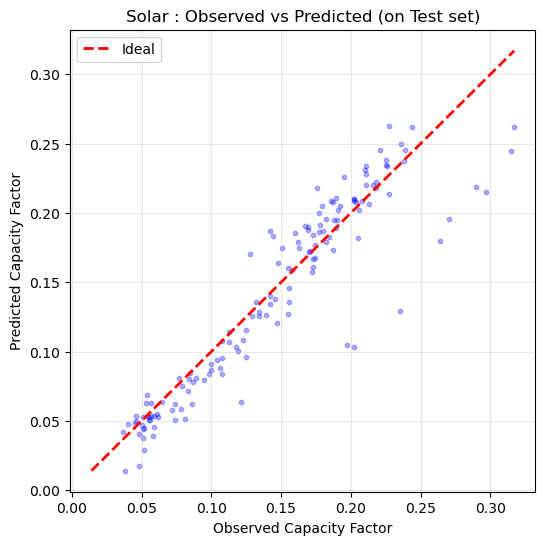

```
Visualization : Wind
```

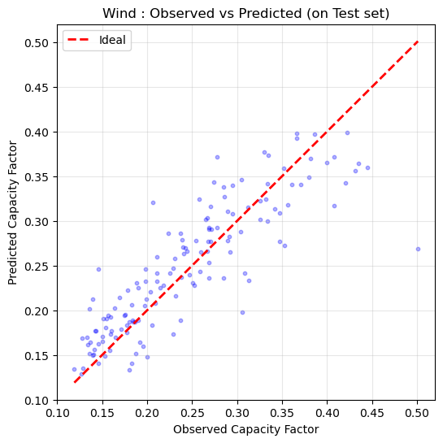

```python
region_etude = 'Bourgogne-Franche-Comté'
# 'Auvergne-Rhône-Alpes', 'Bourgogne-Franche-Comté','Bretagne','Centre-Val de Loire'
# 'Grand Est','Hauts-de-France', 'Normandie','Nouvelle-Aquitaine','Occitanie'
# 'Pays de la Loire',"Provence-Alpes-Côte d'Azur", 'Île-de-France'

# Visualization for solar
scatter_plot(y_test_pv, y_pred_pv, "Solar")
#series_time_plot(y_test_pv, y_pred_pv, test_pv, "Solar", region_etude)

# Visualization for wind
scatter_plot(y_test_wind, y_pred_wind, "Wind")
#series_time_plot(y_test_wind, y_pred_wind, test_wind, "Wind", region_etude)
```

6. **Selection of relevant climate variables**

```
Analysis of the features from the solar model
```

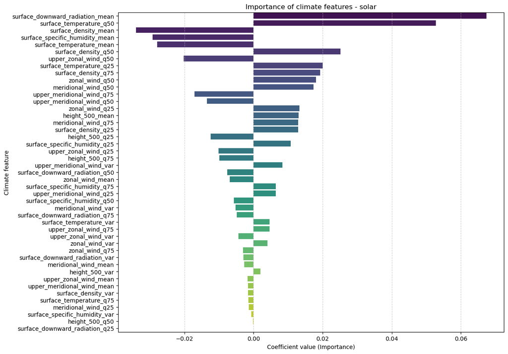

```
Analysis of the features from the wind model
```

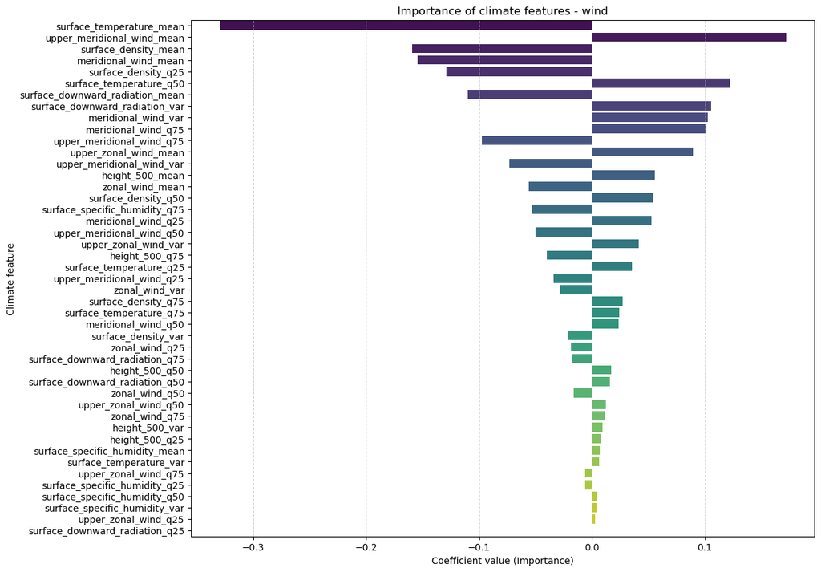

```
Correlation matrix :
```

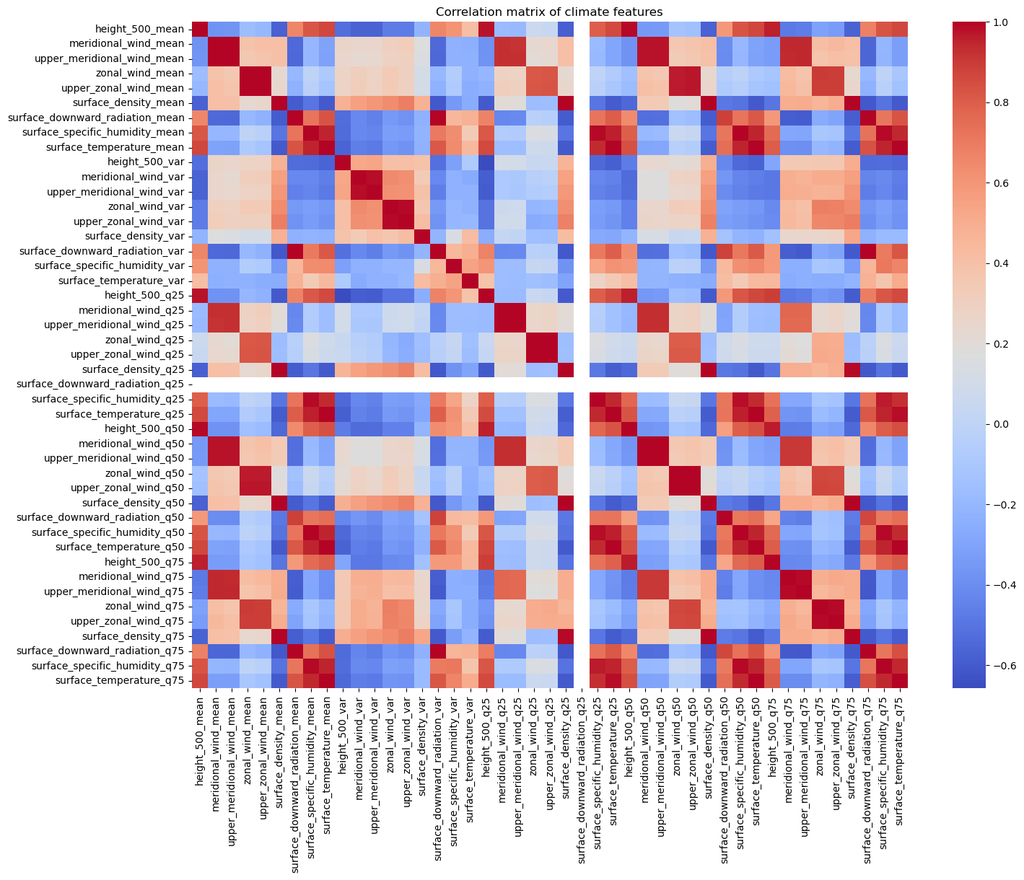

```
Correlation between features and capacity factors :
```

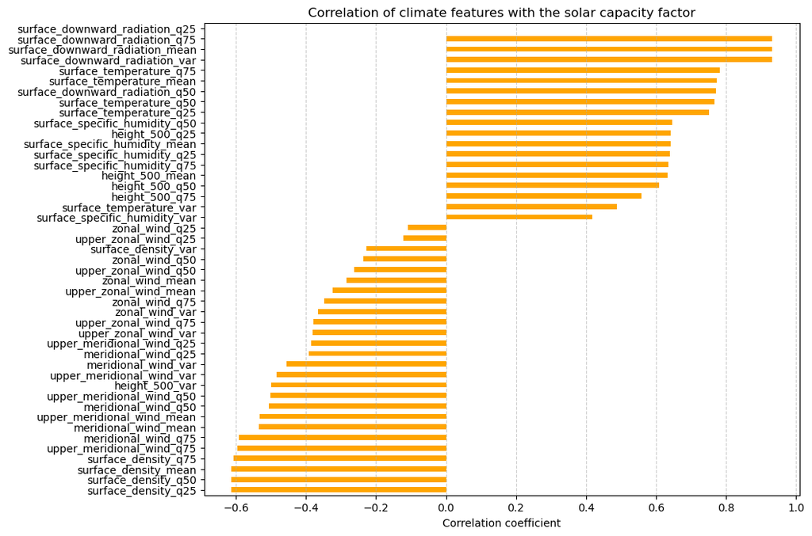

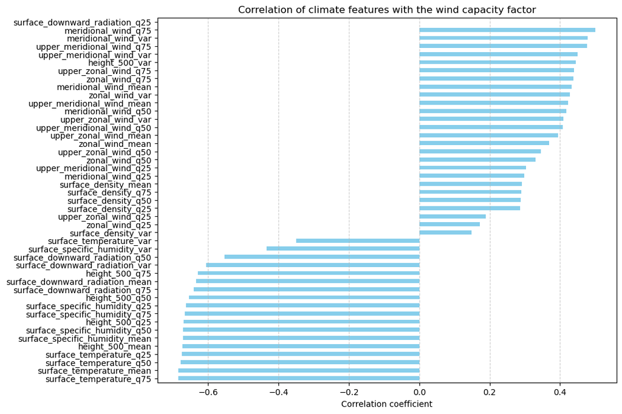

```python
# Representation of features importance in the model

def importance_var_model(model, all_feature_names, numerical_feature_names, title):
    coef_df = pd.DataFrame({'feature': all_feature_names, 'coef': model.coef_})
    # we only look at numerical features
    coef_df = coef_df[coef_df['feature'].isin(numerical_feature_names)]
    coef_df['abs_coef'] = coef_df['coef'].abs()
    coef_df = coef_df.sort_values('abs_coef', ascending=False)
    # Visualization
    plt.figure(figsize=(12, 10))
    sns.barplot(x='coef', y='feature', data=coef_df, palette='viridis')
    plt.title(title)
    plt.xlabel("Coefficient value (Importance)")
    plt.ylabel("Climate feature")
    plt.grid(True, axis='x', linestyle='--', alpha=0.6)
    plt.show()

print("Analysis of the features from the solar model")
importance_var_model(model_pv, features_cols, numerical_cols, "Importance of climate features - solar")

print("Analysis of the features from the wind model")
importance_var_model(model_wind, features_cols, numerical_cols, "Importance of climate features - wind")


# Visualization of the correlation matrix
print("Correlation matrix :")
correlation_matrix = df_final[numerical_cols].corr()
plt.figure(figsize=(16, 12))
sns.heatmap(correlation_matrix, cmap='coolwarm', annot=False)
plt.title("Correlation matrix of climate features")
plt.show()


# Visualization of the correlation between the features and the label
print("Correlation between features and capacity factors :")

corr_with_pv = df_final[numerical_cols + ['cap_factor_pv']].corr()['cap_factor_pv'].drop('cap_factor_pv')
corr_with_wind = df_final[numerical_cols + ['cap_factor_wind']].corr()['cap_factor_wind'].drop('cap_factor_wind')
# solar
plt.figure(figsize=(10, 8))
corr_with_pv.sort_values().plot(kind='barh', color='orange')
plt.title("Correlation of climate features with the solar capacity factor")
plt.xlabel("Correlation coefficient")
plt.grid(True, axis='x', linestyle='--', alpha=0.6)
plt.show()
# wind
plt.figure(figsize=(10, 8))
corr_with_wind.sort_values().plot(kind='barh', color='skyblue')
plt.title("Correlation of climate features with the wind capacity factor")
plt.xlabel("Correlation coefficient")
plt.grid(True, axis='x', linestyle='--', alpha=0.6)
plt.show()
```

**Based on these graphs and our intuition, we choose to study the following variables**

*For solar power* :

- surface_downward_radiation_XX
- surface_temperature_XX
- surface_density_XX
- surface_specific_humidity_XX
- zonal_wind_q50
- meridional_wind_q50

*For wind power* :

- upper_meridional_wind_XX
- upper_zonal_wind_XX
- meridional_wind_XX
- zonal_wind_XX
- surface_temperature_XX
- surface_density_XX
- height_500_XX

In addition to these features, we choose to retain the region encoding (dummy encoding) done previously. We also add two features (cos and sin) encoding the month studied, which allows us to take into account the cyclical nature of the months and thus further contextualize the capacity factor estimate.

All these manipulations are performed using the following function:

```python
def dataset_creation(date_max, date_lim, features_a_garder, pv_or_wind):
    df_ici = df_final.copy()

    df_ici['month'] = df_ici['time'].dt.month
    df_ici['sin_month'] = np.sin(2 * np.pi * df_ici['month'] / 12)
    df_ici['cos_month'] = np.cos(2 * np.pi * df_ici['month'] / 12)

    region_cols = [col for col in df_final.columns if col.startswith('region_')]
    calendar_features = ['sin_month', 'cos_month']
    if pv_or_wind == 'pv':
        vre = 'cap_factor_pv'
    else:
        vre = 'cap_factor_wind'

    final_cols = (['time', vre] +
                    features_a_garder +
                    calendar_features +
                    region_cols)

    df_ici = df_ici[final_cols].copy()


    train_df = df_ici[df_ici['time'].dt.year < date_lim]
    test_df = df_ici[
        (df_ici['time'].dt.year > date_lim - 1) &
        (df_ici['time'].dt.year <= date_max)
        ]

    label = [vre]
    exclude_cols = ['time', 'region_name'] + label
    features_cols = [c for c in train_df.columns if c not in exclude_cols]

    # X, y split
    train_df = train_df.dropna(subset=[vre])
    X_train_df = train_df[features_cols]
    y_train_df = train_df[vre]

    test_df = test_df.dropna(subset=[vre])
    X_test_df = test_df[features_cols]
    y_test_df = test_df[vre]

    return X_train_df, y_train_df, X_test_df, y_test_df
```

## II. Study for solar photovoltaics

1. **Study of an ordinary linear regression trained for solar energy**

We now only take the features selected in Part I. for solar energy in the hope of improving the performance of our ordinary linear regression (OLS).

```python
# Feature selection for the solar model

features_a_garder = ["surface_temperature_mean", "surface_temperature_var", "surface_temperature_q25", "surface_temperature_q50", "surface_temperature_q75", "surface_downward_radiation_mean", "surface_downward_radiation_var", "surface_downward_radiation_q25", "surface_downward_radiation_q50", "surface_downward_radiation_q75", "surface_density_mean", "surface_density_var", "surface_density_q25", "surface_density_q50", "surface_density_q75", "surface_specific_humidity_mean", "surface_specific_humidity_var", "surface_specific_humidity_q25", "surface_specific_humidity_q50", "surface_specific_humidity_q75", "zonal_wind_q50", "meridional_wind_q50"]
X_train_pv, y_train_pv, X_test_pv, y_test_pv = dataset_creation(2019, 2019, features_a_garder, 'pv')

# feature normalization
train_df_num = X_train_pv[features_a_garder].copy()
train_df_num_norm = (train_df_num - train_df_num.mean()) / train_df_num.std()
test_df_num = X_test_pv[features_a_garder].copy()
test_df_num_norm = (test_df_num - train_df_num.mean()) / train_df_num.std()

train_df_num_norm[features_a_garder] = train_df_num_norm[features_a_garder].replace([np.inf, -np.inf], np.nan).fillna(0)
test_df_num_norm[features_a_garder] = test_df_num_norm[features_a_garder].replace([np.inf, -np.inf], np.nan).fillna(0)

X_train_pv[features_a_garder] = train_df_num_norm[features_a_garder]
X_test_pv[features_a_garder] = test_df_num_norm[features_a_garder]

# Modele OLS
model_pv = LinearRegression()

# Train and predict
model_pv.fit(X_train_pv, y_train_pv)
y_pred_pv = model_pv.predict(X_test_pv)
```

Evaluation

```python
print(f"The training R² score is {model_pv.score(X_train_pv, y_train_pv)}")
```

```
The training R² score is 0.9461723380089894
```

```
While the R² score of the test set is : 0.8619.
MAE : 0.0151
RMSE : 0.0248
Visualization : Solar
```

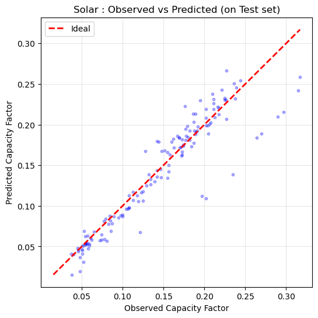

```python
mae_pv = mean_absolute_error(y_test_pv, y_pred_pv)
rmse_pv = np.sqrt(mean_squared_error(y_test_pv, y_pred_pv))
r2_pv = r2_score(y_test_pv, y_pred_pv)

print(f"While the R² score of the test set is : {r2_pv:.4f}.")
print(f"MAE : {mae_pv:.4f}")
print(f"RMSE : {rmse_pv:.4f}")

# Vizualisation
scatter_plot(y_test_pv, y_pred_pv, "Solar")
#series_time_plot(y_test_pv, y_pred_pv, test_pv, "Solar", region_etude)
```

2. **Suspicion of overfitting**

As the test R² is significantly lower than the train R², we suspect that the ordinary linear regression is overfitting.

To study this possible behavior more precisely, we choose to represent a learning curve of the model (with a train/validation split respecting chronological order)

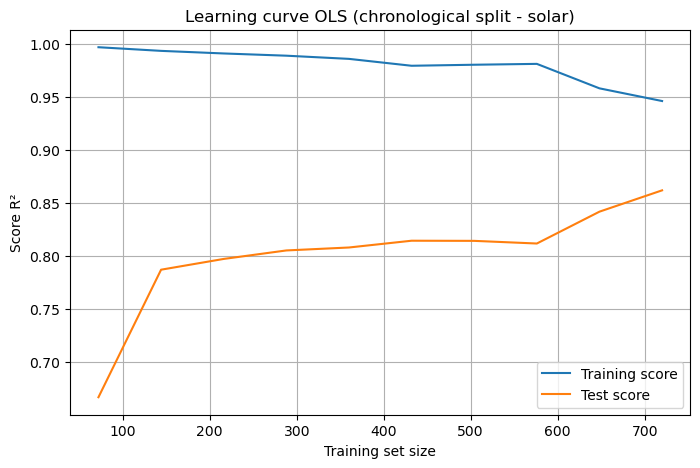

```python
# OLS Learning Curve

train_sizes = np.linspace(0.1, 1.0, 10)
train_scores = []
test_scores = []

n_train = X_train_pv.shape[0]

for frac in train_sizes:
    n = int(frac * n_train)
    X_sub = X_train_pv.iloc[:n]
    y_sub = y_train_pv.iloc[:n]

    model = LinearRegression()
    model.fit(X_sub, y_sub)

    # Score on the training subset
    y_pred_train = model.predict(X_sub)
    train_scores.append(r2_score(y_sub, y_pred_train))

    # Score on the full test set
    y_pred_test = model.predict(X_test_pv)
    test_scores.append(r2_score(y_test_pv, y_pred_test))

plt.figure(figsize=(8,5))
plt.plot(train_sizes * n_train, train_scores, label="Training score")
plt.plot(train_sizes * n_train, test_scores, label="Test score")
plt.xlabel("Training set size")
plt.ylabel("Score R²")
plt.title("Learning curve OLS (chronological split - solar)")
plt.legend()
plt.grid(True)
plt.show()
```

This learning curve suggests that there is no overfitting, as the model is not plateauing but continues to improve as the number of data increases, meaning that the model is not yet “too complex.”

However, this difference between the R² values suggests that our model does not generalize well for the year 2019 (test year).

Facing this question, our hypothesis is that we are studying highly correlated variables (5 different features per climate variable + related variables) and as the course shows, this correlation between features is likely to create very large coefficients that offset each other in our model. Very large coefficients can amplify the noise in the data of the test year (2019), which would explain the poor generalization to 2019 and the low R² of the testing set compared to the training set.

To test this hypothesis, we decide to reduce the size of the coefficients in the model to increase stability by performing regularization.

To do so we use a Ridge regression on our data.

3. **A first regularisation technique : Ridge regression**

First, we use a cross-validation to find the optimal regularisation hyperparameter of the ridge regression on ou training set.

```
Ridge regression with KFold on the training data for various alpha values
```

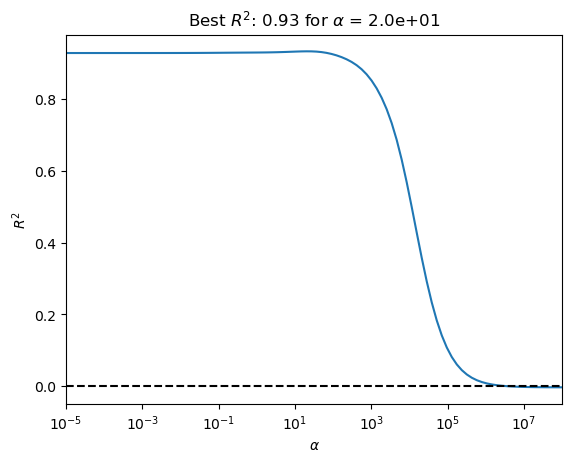

```python
print("Ridge regression with KFold on the training data for various alpha values")

reg_class = linear_model.Ridge

ALPHA_RNG_RIDGE = np.logspace(-5, 8, 100)
complexity_rng = ALPHA_RNG_RIDGE

# Number of splits for the cross validation
n_splits_cv = 5


r2_validation = np.empty(complexity_rng.shape)
coefs = np.empty((len(complexity_rng), X_train_pv.shape[1]))

for k, complexity in enumerate(complexity_rng):

    reg = reg_class(alpha=complexity)

    # r2 test scores of the k-fold cross-validation
    r2_validation_arr = cross_val_score(reg, X_train_pv, y_train_pv, cv=n_splits_cv)

    # r2 predicted as a mean of the validation scores
    r2_validation[k] = r2_validation_arr.mean()

    reg.fit(X_train_pv, y_train_pv)
    coefs[k] = reg.coef_

# Keep the best hyperparmeter value and predict the model coefficients.
i_best = np.argmax(r2_validation)
complexity_best_ridge = complexity_rng[i_best]
r2_best = r2_validation[i_best]
coefs_best = coefs[i_best]

# Validation curve
complexity_label = r'$\alpha$'
plt.figure()
plt.plot(complexity_rng, r2_validation)
plt.hlines(0., *complexity_rng[[0, -1]], colors='k', linestyles='--')
plt.xscale('log')
plt.xlabel(complexity_label)
plt.ylabel(r'$R^2$')
_ = plt.title(r'Best $R^2$: {:.2} for $\alpha$ = {:.1e}'.format(
    r2_best, complexity_best_ridge))
_ = plt.xlim(complexity_rng[[0, -1]])
```

This curve shows us the best value for alpha on the training set.

Then we choose to represent the distribution of the model coefficients in two settings :

- for the OLS regression (without regularization)
- for the ridge regression (with the optimized alpha)

This is to make sure that the ridge regression really has an impact on the coefficient of the model (and thus to verify that regularisation has a point here)

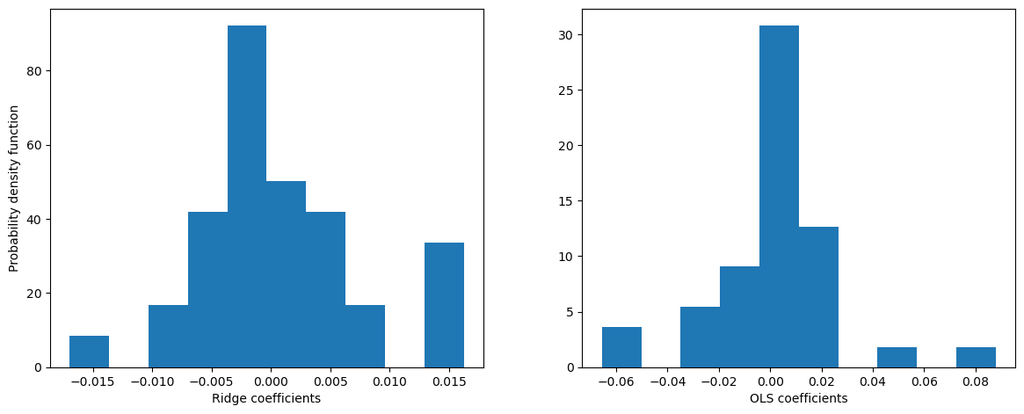

```python
figsize = np.array(plt.rcParams['figure.figsize']) * np.array([2, 1.2])
fig, ax = plt.subplots(1, 2, figsize=figsize)
fig.tight_layout(pad=5.0)

# Ridge coefficients with the best alpha
ax[0].hist(coefs_best, density=True)
ax[0].set_xlabel(r'Ridge coefficients')
ax[0].set_ylabel('Probability density function')

# OLS coefficients
ax[1].hist(coefs[0], density=True)
_ = ax[1].set_xlabel(r'OLS coefficients')
```

Finally, we observe wether this regularisation process has an effect on the model performance in termes of R² score.

```python
# Ridge with the best alpha
reg = reg_class(alpha=complexity_best_ridge)

reg.fit(X_train_pv, y_train_pv)

r2_train = reg.score(X_train_pv, y_train_pv)
r2_test = reg.score(X_test_pv, y_test_pv)

print('The train R² score is : {:.2f}'.format(r2_train))
print('While the test R² score is : {:.2f}'.format(r2_test))
```

```
The train R² score is : 0.94
While the test R² score is : 0.84
```

As we are not satisfied by our test R² score regarding the train R² score and the previous test R² score that was higher, we choose to try a more severe regularisation technique in termes of impact on the model coefficients : the Lasso regression.

4. **A second regularisation technique : Lasso regression**

As we did with the ridge regression, we first choose to optimize the lasso regression hyperparameter with a cross validation on the train set. And we also represent the coefficient distribution for the OLS regression and the Lasso regression.

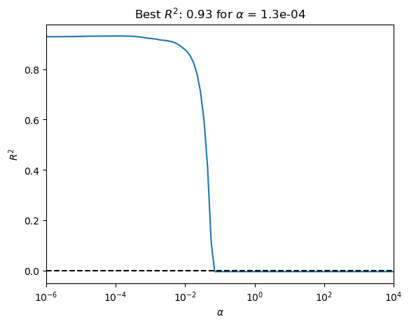

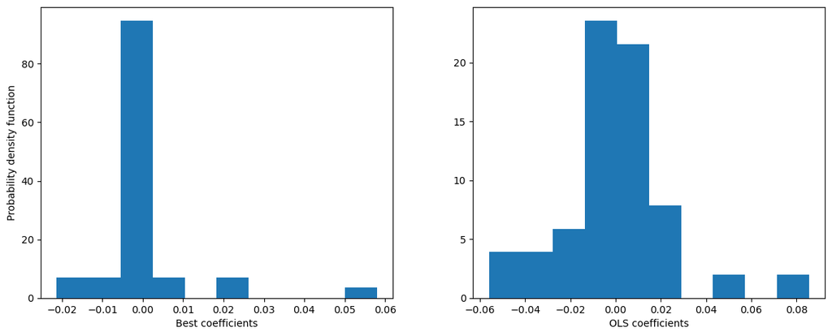

```python
reg_class = linear_model.Lasso

kwargs_lasso = dict(max_iter=30000)

ALPHA_RNG_LASSO = np.logspace(-6, 4, 100)
complexity_rng = ALPHA_RNG_LASSO

# number of split
n_splits_cv = 5


r2_validation = np.empty(complexity_rng.shape)
coefs = np.empty((len(complexity_rng), X_train_pv.shape[1]))

for k, complexity in enumerate(complexity_rng):
    reg = reg_class(alpha=complexity, **kwargs_lasso)

    r2_validation_arr = cross_val_score(reg, X_train_pv, y_train_pv, cv=n_splits_cv)

    r2_validation[k] = r2_validation_arr.mean()

    reg.fit(X_train_pv, y_train_pv)
    coefs[k] = reg.coef_

i_best = np.argmax(r2_validation)
complexity_best_lasso = complexity_rng[i_best]
r2_best = r2_validation[i_best]
coefs_best = coefs[i_best]

alpha_label = r'$\alpha$'
plt.figure()
plt.plot(complexity_rng, r2_validation)
plt.hlines(0., *complexity_rng[[0, -1]], colors='k', linestyles='--')
plt.xscale('log')
plt.xlabel(alpha_label)
plt.ylabel(r'$R^2$')
_ = plt.title(r'Best $R^2$: {:.2} for $\alpha$ = {:.1e}'.format(
    r2_best, complexity_best_lasso))
_ = plt.xlim(complexity_rng[[0, -1]])


figsize = np.array(plt.rcParams['figure.figsize']) * np.array([2, 1.2])
fig, ax = plt.subplots(1, 2, figsize=figsize)
fig.tight_layout(pad=5.0)

# plot of the Lasso coefficients (with the best regularization hyperparameter)
ax[0].hist(coefs_best, density=True)
ax[0].set_xlabel(r'Best coefficients')
ax[0].set_ylabel('Probability density function')

# plot of the OLS coefficients
ax[1].hist(coefs[0], density=True)
_ = ax[1].set_xlabel(r'OLS coefficients')
```

We can see with the figure above that the Lasso regularisation has a great impact on the coefficient of the model, it reduces most of the coefficients to zero, conforting us in the idea that the high correlation between features is pushing the model towards creating huge competing coefficients and that a strong regularisation could change that.

We can now see if it had a further impact on the test R² compared to the ridge regularisation.

```python
reg = reg_class(alpha=complexity_best_lasso, **kwargs_lasso)

reg.fit(X_train_pv, y_train_pv)

r2_train = reg.score(X_train_pv, y_train_pv)
r2_test = reg.score(X_test_pv, y_test_pv)

print('The train R² score is : {:.2f}'.format(r2_train))
print('While the test R² score is : {:.2f}'.format(r2_test))
```

```
The train R² score is : 0.94
While the test R² score is : 0.86
```

Lasso does better that Ridge, however it does not improve the test R² compared to the OLS and it thus means that eventhough the correlation between features is very high (as the lasso model managed to achieve a comparable R² score with many coefficient turned down to zero), the noise enhanced by the model huge coefficient is not the main issue with our regression.

Our next hypothesis to explain why the model is not performing well on the year 2019 (test set), is that the dataset distribution is not iid, and that there is a shift of distribution across time and especially during the year 2019 (which could have been a very warm year for example).

5. **Study of the data distribution**

To test this hypothesis we choose to change our test/train split methode. We randomly select 80% of months for the train set and 20% of months for the test set. This results in similar empirical distributions for both sets, ie we force training and testing to be similar and prevent a time lag.

If the data distribution is indeed the issue with our regression problem, this randomized split technique should improve the test R², and the train and test R² should be much more similar.

We split the data with this new function :

```python
def random_split(random_state, features_a_garder, pv_or_wind):
    df_ici = df_final.copy()

    df_ici['month'] = df_ici['time'].dt.month
    df_ici['sin_month'] = np.sin(2 * np.pi * df_ici['month'] / 12)
    df_ici['cos_month'] = np.cos(2 * np.pi * df_ici['month'] / 12)

    region_cols = [col for col in df_final.columns if col.startswith('region_')]
    calendar_features = ['sin_month', 'cos_month']
    if pv_or_wind == 'pv':
        vre = 'cap_factor_pv'
    else:
        vre = 'cap_factor_wind'

    final_cols = (['time', vre] +
                    features_a_garder +
                    calendar_features +
                    region_cols)

    df_ici = df_ici[final_cols].copy()

    train_df, test_df, train_months, test_months = split_by_random_months(df_ici, prop=0.8, random_state=random_state)

    label = [vre]
    exclude_cols = ['time', 'region_name'] + label
    features_cols = [c for c in train_df.columns if c not in exclude_cols]

    train_df = train_df.dropna(subset=[vre])
    X_train_df = train_df[features_cols]
    y_train_df = train_df[vre]

    test_df = test_df.dropna(subset=[vre])
    X_test_df = test_df[features_cols]
    y_test_df = test_df[vre]

    return X_train_df, y_train_df, X_test_df, y_test_df


# With the following function allowing us to randomly select months from the dataset
# to perform a test/train split with the most random distribution possible.

def split_by_random_months(df, prop=0.8, random_state=42):
    df = df.copy()
    df["year_month"] = df["time"].dt.to_period("M")

    months = df["year_month"].unique()

    rng = np.random.default_rng(random_state)
    rng.shuffle(months)

    n_months_train = int(len(months) * prop)
    train_months = months[:n_months_train]
    test_months = months[n_months_train:]

    train_df = df[df["year_month"].isin(train_months)].drop(columns="year_month")
    test_df  = df[df["year_month"].isin(test_months)].drop(columns="year_month")

    return train_df, test_df, train_months, test_months
```

And we train our OLS model with this new random split

```
The training R² score is 0.9306178978410123
While the test R² score is: 0.9380.
MAE : 0.0115
RMSE : 0.0172
Visualization : Solar - Random Months Split
```

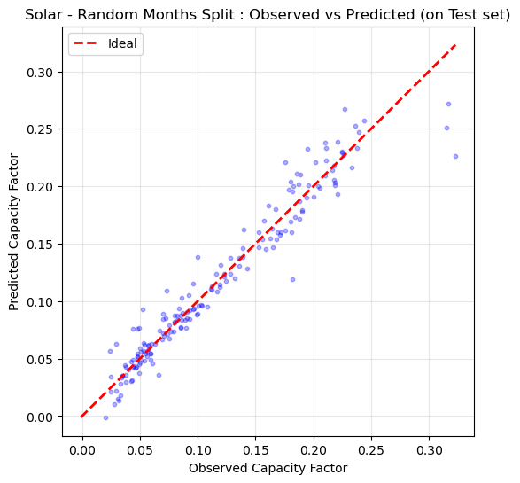

```python
X_train_pv, y_train_pv, X_test_pv, y_test_pv = random_split(42, features_a_garder, 'pv')

# normalization of features
train_df_num = X_train_pv[features_a_garder].copy()
train_df_num_norm = (train_df_num - train_df_num.mean()) / train_df_num.std()
test_df_num = X_test_pv[features_a_garder].copy()
test_df_num_norm = (test_df_num - train_df_num.mean()) / train_df_num.std()

train_df_num_norm[features_a_garder] = train_df_num_norm[features_a_garder].replace([np.inf, -np.inf], np.nan).fillna(0)
test_df_num_norm[features_a_garder] = test_df_num_norm[features_a_garder].replace([np.inf, -np.inf], np.nan).fillna(0)

train_df[features_a_garder] = train_df_num_norm[features_a_garder]
test_df[features_a_garder] = test_df_num_norm[features_a_garder]

# OLS model
model_pv = LinearRegression()

# Train and predict
model_pv.fit(X_train_pv, y_train_pv)
y_pred_pv = model_pv.predict(X_test_pv)

# solar evaluation
print(f"The training R² score is {model_pv.score(X_train_pv, y_train_pv)}")

mae_pv = mean_absolute_error(y_test_pv, y_pred_pv)
rmse_pv = np.sqrt(mean_squared_error(y_test_pv, y_pred_pv))
r2_pv = r2_score(y_test_pv, y_pred_pv)

print(f"While the test R² score is: {r2_pv:.4f}.")
print(f"MAE : {mae_pv:.4f}")
print(f"RMSE : {rmse_pv:.4f}")

# visualization
scatter_plot(y_test_pv, y_pred_pv, "Solar - Random Months Split")
```

These resuts show that there is indeed a data distribution problem.

To visualy see this distribution problem in the data, we decieded to use a PCA.

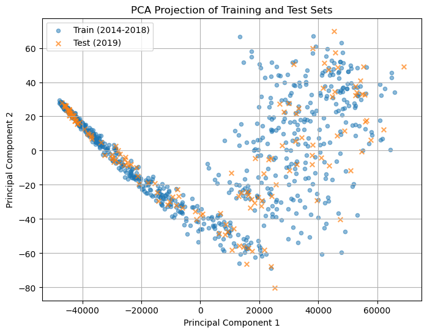

```python
from sklearn.decomposition import PCA

X_train_pv, y_train_pv, X_test_pv, y_test_pv = dataset_creation(2019, 2019, features_a_garder, 'pv')

region_cols = [col for col in df_final.columns if col.startswith('region_')]

# On suppose que train_df et test_df sont déjà définis
# On retire les colonnes non numériques et la cible

exclude_cols = ['time', 'cap_factor_pv', 'cap_factor_wind'] + region_cols
features_pca = [c for c in X_train_pv.columns if c not in exclude_cols]


# On retire les lignes avec NaN dans les features
X_train_pca = X_train_pv[features_pca].dropna()
X_test_pca = X_test_pv[features_pca].dropna()

# On ajuste la PCA sur le train uniquement
pca = PCA(n_components=2)
X_train_proj = pca.fit_transform(X_train_pca)
X_test_proj = pca.transform(X_test_pca)

plt.figure(figsize=(8,6))
plt.scatter(X_train_proj[:,0], X_train_proj[:,1], alpha=0.5, label="Train (2014-2018)", c='tab:blue', s=20)
plt.scatter(X_test_proj[:,0], X_test_proj[:,1], alpha=0.7, label="Test (2019)", c='tab:orange', s=30, marker='x')
plt.xlabel("Principal Component 1")
plt.ylabel("Principal Component 2")
plt.title("PCA Projection of Training and Test Sets")
plt.legend()
plt.grid(True)
plt.show()
```

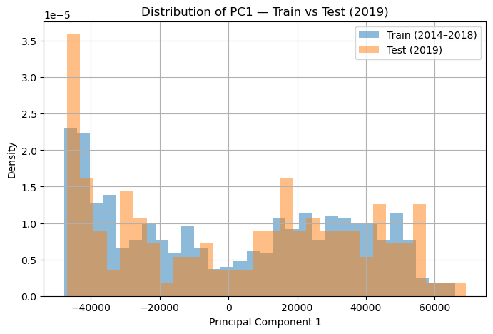

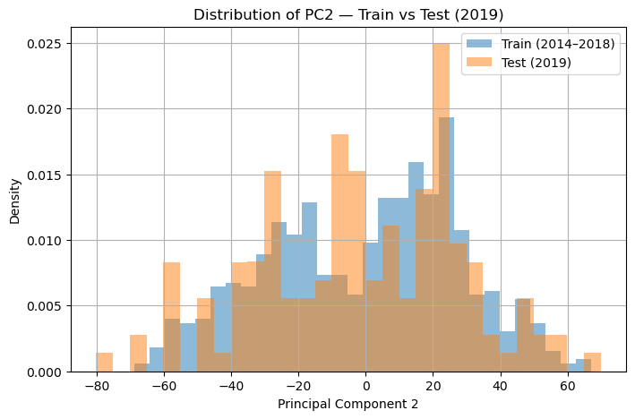

```python
# recuperation of PC1
pc1_train = X_train_proj[:, 0]
pc1_test = X_test_proj[:, 0]

plt.figure(figsize=(8, 5))

plt.hist(
    pc1_train,
    bins=30,
    density=True,
    alpha=0.5,
    label="Train (2014–2018)",
    color="tab:blue"
)

plt.hist(
    pc1_test,
    bins=30,
    density=True,
    alpha=0.5,
    label="Test (2019)",
    color="tab:orange"
)

plt.xlabel("Principal Component 1")
plt.ylabel("Density")
plt.title("Distribution of PC1 — Train vs Test (2019)")
plt.legend()
plt.grid(True)
plt.show()

# recuperation of PC2
pc2_train = X_train_proj[:, 1]
pc2_test = X_test_proj[:, 1]

plt.figure(figsize=(8, 5))

plt.hist(
    pc2_train,
    bins=30,
    density=True,
    alpha=0.5,
    label="Train (2014–2018)",
    color="tab:blue"
)

plt.hist(
    pc2_test,
    bins=30,
    density=True,
    alpha=0.5,
    label="Test (2019)",
    color="tab:orange"
)

plt.xlabel("Principal Component 2")
plt.ylabel("Density")
plt.title("Distribution of PC2 — Train vs Test (2019)")
plt.legend()
plt.grid(True)
plt.show()
```

## III. Study for onshore wind power

1. **Training of a new supervised regression**

```python
features_a_garder = ["upper_meridional_wind_q25","upper_meridional_wind_q50","upper_meridional_wind_q75","upper_meridional_wind_mean","upper_meridional_wind_var",
                      "upper_zonal_wind_q25","upper_zonal_wind_q50","upper_zonal_wind_q75","upper_zonal_wind_mean","upper_zonal_wind_var",
                      "meridional_wind_q25","meridional_wind_q50","meridional_wind_q75","meridional_wind_mean","meridional_wind_var",
                      "zonal_wind_q25","zonal_wind_q50","zonal_wind_q75","zonal_wind_mean","zonal_wind_var",
                      "surface_temperature_q25","surface_temperature_q50","surface_temperature_q75","surface_temperature_mean","surface_temperature_var",
                      "surface_density_q25","surface_density_q50","surface_density_q75","surface_density_mean","surface_density_var",
                      "height_500_q25","height_500_q50","height_500_q75","height_500_mean","height_500_var"]
```

We make the hypothesis that a linear regression is a model too simple to capture the link between athmospheric conditions and wind power capacity factor (this hypothesis is motivated by the fact that wind power is proportional to the cube of wind speed).

To verify this we represent the learning curve of an OLS regression with the wind data set (with a randomization of the data set).

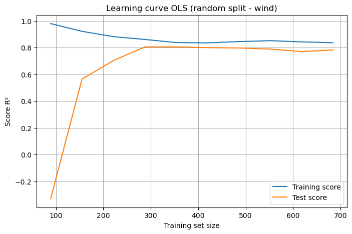

```python
X_train_wind, y_train_wind, X_test_wind, y_test_wind = random_split(78, features_a_garder, 'wind')

# normalization of features
train_df_num = X_train_wind[features_a_garder].copy()
train_df_num_norm = (train_df_num - train_df_num.mean()) / train_df_num.std()
test_df_num = X_test_wind[features_a_garder].copy()
test_df_num_norm = (test_df_num - train_df_num.mean()) / train_df_num.std()

train_df_num_norm[features_a_garder] = train_df_num_norm[features_a_garder].replace([np.inf, -np.inf], np.nan).fillna(0)
test_df_num_norm[features_a_garder] = test_df_num_norm[features_a_garder].replace([np.inf, -np.inf], np.nan).fillna(0)

X_train_wind[features_a_garder] = train_df_num_norm[features_a_garder]
X_test_wind[features_a_garder] = test_df_num_norm[features_a_garder]


# OLS Learning Curve

train_sizes = np.linspace(0.13, 1.0, 10)
train_scores = []
test_scores = []

n_train = X_train_wind.shape[0]

for frac in train_sizes:
    n = int(frac * n_train)
    X_sub = X_train_wind.iloc[:n]
    y_sub = y_train_wind.iloc[:n]

    model = LinearRegression()
    model.fit(X_sub, y_sub)

    # Score on the training subset
    y_pred_train = model.predict(X_sub)
    train_scores.append(r2_score(y_sub, y_pred_train))

    # Score on the full test set
    y_pred_test = model.predict(X_test_wind)
    test_scores.append(r2_score(y_test_wind, y_pred_test))

plt.figure(figsize=(8,5))
plt.plot(train_sizes * n_train, train_scores, label="Training score")
plt.plot(train_sizes * n_train, test_scores, label="Test score")
plt.xlabel("Training set size")
plt.ylabel("Score R²")
plt.title("Learning curve OLS (random split - wind)")
plt.legend()
plt.grid(True)
plt.show()
```

Indeed the OLS regression seem to be to simple for this task. So we decied to use a morel complex model that is better with non-linearities :

- Random Forest

```python
X_train_wind, y_train_wind, X_test_wind, y_test_wind = dataset_creation(2019, 2019, features_a_garder, 'wind')

# feature normalization
train_df_num = X_train_wind[features_a_garder].copy()
train_df_num_norm = (train_df_num - train_df_num.mean()) / train_df_num.std()
test_df_num = X_test_wind[features_a_garder].copy()
test_df_num_norm = (test_df_num - train_df_num.mean()) / train_df_num.std()

train_df_num_norm[features_a_garder] = train_df_num_norm[features_a_garder].replace([np.inf, -np.inf], np.nan).fillna(0)
test_df_num_norm[features_a_garder] = test_df_num_norm[features_a_garder].replace([np.inf, -np.inf], np.nan).fillna(0)

X_train_wind[features_a_garder] = train_df_num_norm[features_a_garder]
X_test_wind[features_a_garder] = test_df_num_norm[features_a_garder]

# Random Forest model
rf = RandomForestRegressor(
    n_estimators=500,
    random_state=42,
    n_jobs=-1
)


rf.fit(X_train_wind, y_train_wind)
y_pred = rf.predict(X_test_wind)
```

Evaluation

```python
# Evaluation
mae = mean_absolute_error(y_test_wind, y_pred)
rmse = np.sqrt(mean_squared_error(y_test_wind, y_pred))
r2 = r2_score(y_test_wind, y_pred)

print(f"MAE  : {mae:.4f}")
print(f"RMSE : {rmse:.4f}")
print(f"R²   : {r2:.4f}")
```

```
MAE  : 0.0391
RMSE : 0.0508
R²   : 0.6348
```

Visualization

```
Visualization : Wind
```

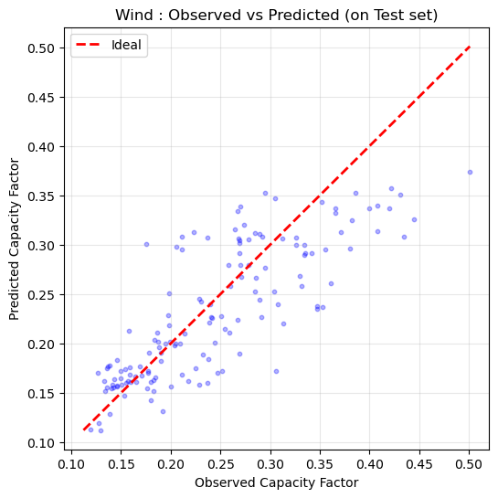

```python
scatter_plot(y_test_wind, y_pred, "Wind")
#series_time_plot(y_test_wind, y_pred, test_wind, "Wind", region_etude)
```

We represent the learning curve to determine how our model can be optimized (performed with a random split of the data)

[figure not shown]

```python
X_train_wind, y_train_wind, X_test_wind, y_test_wind = random_split(78, features_a_garder, 'wind')

# normalization of features
train_df_num = X_train_wind[features_a_garder].copy()
train_df_num_norm = (train_df_num - train_df_num.mean()) / train_df_num.std()
test_df_num = X_test_wind[features_a_garder].copy()
test_df_num_norm = (test_df_num - train_df_num.mean()) / train_df_num.std()

train_df_num_norm[features_a_garder] = train_df_num_norm[features_a_garder].replace([np.inf, -np.inf], np.nan).fillna(0)
test_df_num_norm[features_a_garder] = test_df_num_norm[features_a_garder].replace([np.inf, -np.inf], np.nan).fillna(0)

X_train_wind[features_a_garder] = train_df_num_norm[features_a_garder]
X_test_wind[features_a_garder] = test_df_num_norm[features_a_garder]




# RF Learning Curve

train_sizes = np.linspace(0.05, 1.0, 10)
train_scores = []
test_scores = []

n_train = X_train_wind.shape[0]

for frac in train_sizes:
    n = int(frac * n_train)
    X_sub = X_train_wind.iloc[:n]
    y_sub = y_train_wind.iloc[:n]

    model = rf
    model.fit(X_sub, y_sub)

    # Score on the training subset
    y_pred_train = model.predict(X_sub)
    train_scores.append(r2_score(y_sub, y_pred_train))

    # Score on the full test set
    y_pred_test = model.predict(X_test_wind)
    test_scores.append(r2_score(y_test_wind, y_pred_test))

plt.figure(figsize=(8,5))
plt.plot(train_sizes * n_train, train_scores, label="Training score")
plt.plot(train_sizes * n_train, test_scores, label="Test score")
plt.xlabel("Training set size")
plt.ylabel("Score R²")
plt.title("Learning curve Random Forest (chronological split - wind)")
plt.legend()
plt.grid(True)
plt.show()
```

Beyond the data distribution problem (visible when comparing the test R² on the learning curbe and on the previous code cell), this learning curve shows us that the model is overfitting. Thus to improve our R² we decied to try to optimise the model hyperparameters to reduce the model's variance.

2. **Hyperparameter optimization**

To optimize the RF model we use OOB-based validation curves : we choose to vary different hyperparameters and to represent the evolution of the OOB error for each variation, this way we can determine the hyperparameter value that minimizes the error, and maximizes the model performance.

We start with the default hyperparameters and we start by optimizing the hyperparameter "n_estimators" which is the number of trees in the forest, it is arguably the most important hyperparameter for forests.

```
n_estimators: 10, OOB Error: 0.2636
n_estimators: 25, OOB Error: 0.1778
n_estimators: 50, OOB Error: 0.1613
n_estimators: 75, OOB Error: 0.1576
n_estimators: 100, OOB Error: 0.1583
n_estimators: 150, OOB Error: 0.1579
n_estimators: 200, OOB Error: 0.1591
n_estimators: 300, OOB Error: 0.1592
n_estimators: 400, OOB Error: 0.1585
n_estimators: 500, OOB Error: 0.1594
```

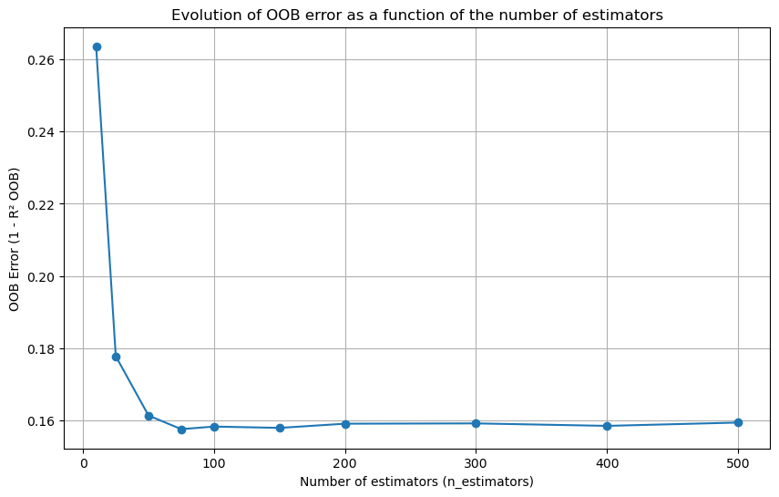

```python
# Optimization of the number of trees (n_estimators)

X_train_wind, y_train_wind, X_test_wind, y_test_wind = dataset_creation(2019, 2019, features_a_garder, 'wind')

# Normalization not necessary for Random Forest
# Values to test for n_estimators
estimator_range = [10, 25, 50, 75, 100, 150, 200, 300, 400, 500]
oob_errors = []

for n_estimators in estimator_range:
    rf = RandomForestRegressor(
        n_estimators=n_estimators,
        random_state=42,
        oob_score=True,
        n_jobs=-1)
    rf.fit(X_train_wind, y_train_wind)
    oob_error = 1 - rf.oob_score_
    oob_errors.append(oob_error)
    print(f"n_estimators: {n_estimators}, OOB Error: {oob_error:.4f}")

# visualisation
plt.figure(figsize=(10, 6))
plt.plot(estimator_range, oob_errors, marker='o', linestyle='-')
plt.title("Evolution of OOB error as a function of the number of estimators")
plt.xlabel("Number of estimators (n_estimators)")
plt.ylabel("OOB Error (1 - R² OOB)")
plt.grid(True)
plt.show()
```

```
max_features: 1, OOB Error: 0.1944
max_features: 2, OOB Error: 0.1812
max_features: 3, OOB Error: 0.1712
max_features: 5, OOB Error: 0.1635
max_features: 8, OOB Error: 0.1550
max_features: 10, OOB Error: 0.1543
max_features: 15, OOB Error: 0.1509
max_features: 20, OOB Error: 0.1559
max_features: 25, OOB Error: 0.1564
max_features: 30, OOB Error: 0.1561
max_features: 40, OOB Error: 0.1605
max_features: 50, OOB Error: 0.1583
```

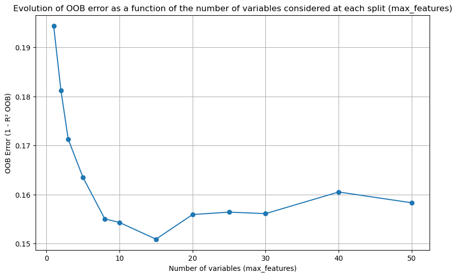

```python
# Optimization of the number of variables considered at each split (max_features)

# Values to test for max_features
max_features_range = [1, 2, 3, 5, 8, 10, 15, 20, 25, 30, 40, 50]
oob_errors = []

for max_features in max_features_range:
    rf = RandomForestRegressor(
        n_estimators=100,
        max_features=max_features,
        random_state=42,
        oob_score=True,
        n_jobs=-1)
    rf.fit(X_train_wind, y_train_wind)
    oob_error = 1 - rf.oob_score_
    oob_errors.append(oob_error)
    print(f"max_features: {max_features}, OOB Error: {oob_error:.4f}")

# visualisation
plt.figure(figsize=(10, 6))
plt.plot(max_features_range, oob_errors, marker='o', linestyle='-')
plt.title("Evolution of OOB error as a function of the number of variables considered at each split (max_features)")
plt.xlabel("Number of variables (max_features)")
plt.ylabel("OOB Error (1 - R² OOB)")
plt.grid(True)
plt.show()
```

```
max_depth: 3, OOB Error: 0.2923
max_depth: 5, OOB Error: 0.2006
max_depth: 7, OOB Error: 0.1642
max_depth: 10, OOB Error: 0.1539
max_depth: 13, OOB Error: 0.1503
max_depth: 15, OOB Error: 0.1531
max_depth: 18, OOB Error: 0.1555
max_depth: 20, OOB Error: 0.1550
max_depth: 23, OOB Error: 0.1543
max_depth: 25, OOB Error: 0.1543
max_depth: 28, OOB Error: 0.1543
max_depth: 30, OOB Error: 0.1543
```

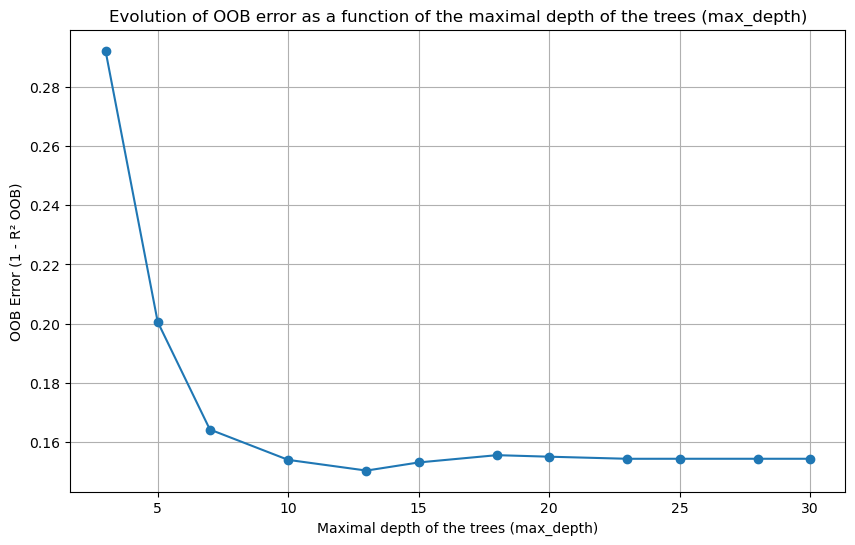

```python
# Optimization of the maximal depth of the trees (max_depth)

# Values to test for max_depth
max_depth_range = [3, 5, 7, 10, 13, 15, 18, 20, 23, 25, 28, 30]
oob_errors = []

for max_depth in max_depth_range:
    rf = RandomForestRegressor(
        n_estimators=100,
        max_features=10,
        max_depth=max_depth,
        random_state=42,
        oob_score=True,
        n_jobs=-1)
    rf.fit(X_train_wind, y_train_wind)
    oob_error = 1 - rf.oob_score_
    oob_errors.append(oob_error)
    print(f"max_depth: {max_depth}, OOB Error: {oob_error:.4f}")

# visualisation
plt.figure(figsize=(10, 6))
plt.plot(max_depth_range, oob_errors, marker='o', linestyle='-')
plt.title("Evolution of OOB error as a function of the maximal depth of the trees (max_depth)")
plt.xlabel("Maximal depth of the trees (max_depth)")
plt.ylabel("OOB Error (1 - R² OOB)")
plt.grid(True)
plt.show()
```

Ultimatly, our optimal parameters are :

```
Training R²: 0.9782
Testing R²:  0.6646
MAE on test set: 0.0370
RMSE on test set: 0.0487
Visualization : Wind
```

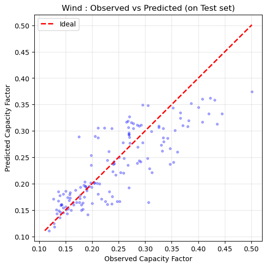

```python
# Model evaluation with the optimized hyperparameters

final_rf = RandomForestRegressor(
    n_estimators=100,
    max_features=10,
    max_depth=13,
    random_state=42,
    n_jobs=-1
)

final_rf.fit(X_train_wind, y_train_wind)

# Comparision of training score and testing score
train_score = final_rf.score(X_train_wind, y_train_wind)
test_score = final_rf.score(X_test_wind, y_test_wind)
y_pred = final_rf.predict(X_test_wind)
mae = mean_absolute_error(y_test_wind, y_pred)
rmse = np.sqrt(mean_squared_error(y_test_wind, y_pred))

print(f"Training R²: {train_score:.4f}")
print(f"Testing R²:  {test_score:.4f}")
print(f"MAE on test set: {mae:.4f}")
print(f"RMSE on test set: {rmse:.4f}")

scatter_plot(y_test_wind, y_pred, "Wind")
#series_time_plot(y_test_wind, y_pred, test_wind, "Wind", region_etude)
```

4. **Training of another new supervised regression**

The Random Forest did not performe better than the linear regression, but the manual optimization we did, was not optimal since we optimized parameters by hand and most of all sequenciently.

Knowing this, we want to try another powerful model : XGBoost ; but we want to optimize it with a library made for optimization to try to improve the wind capacity factor estimation as much as possible. We will thus use the library Optuna to optimize our model.

```python
from xgboost import XGBRegressor
```

```python
import optuna
```

```python
X_train_wind, y_train_wind, X_test_wind, y_test_wind = dataset_creation(2019, 2019, features_a_garder, 'wind')


# Optuna objectives
def objective(trial):
    params = {
        "n_estimators": trial.suggest_int("n_estimators", 300, 2000),
        "learning_rate": trial.suggest_float("learning_rate", 1e-3, 0.2, log=True),
        "max_depth": trial.suggest_int("max_depth", 2, 12),
        "min_child_weight": trial.suggest_float("min_child_weight", 1e-2, 50.0, log=True),
        "subsample": trial.suggest_float("subsample", 0.5, 1.0),
        "colsample_bytree": trial.suggest_float("colsample_bytree", 0.5, 1.0),
        "gamma": trial.suggest_float("gamma", 0.0, 10.0),
        "reg_alpha": trial.suggest_float("reg_alpha", 1e-8, 10.0, log=True),
        "reg_lambda": trial.suggest_float("reg_lambda", 1e-8, 100.0, log=True),
        "objective": "reg:squarederror",
        "random_state": 42,
        "n_jobs": -1,
        "tree_method": "hist",
    }

    model = XGBRegressor(**params)

    model.fit(
        X_train_wind, y_train_wind,
        eval_set=[(X_test_wind, y_test_wind)],
        verbose=False
    )

    y_pred = model.predict(X_test_wind)
    rmse = np.sqrt(mean_squared_error(y_test_wind, y_pred))
    return rmse

# Here start the optimization, WARNING n_trials is a very important paramater to choose
study = optuna.create_study(direction="minimize")
study.optimize(objective, n_trials=50, show_progress_bar=True)

print("Best hyperparameters:", study.best_params)
print("Best RMSE (val):", study.best_value)
```

```
[I 2025-12-14 19:51:13,355] A new study created in memory with name: no-name-3a3d9687-937d-4911-9faa-8d8d1b3d8853
```

[output not shown]

[output cut: 38 more lines]

5. **Evaluation of the optimized model**

```
Train R²   : 0.9027
Test R²   : 0.6787
MAE  : 0.0360
RMSE : 0.0477
Visualization : Wind
```

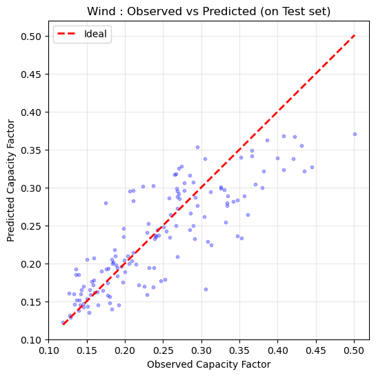

```python
# Training with the best hyperparameters
best_params = study.best_params.copy()
best_params.update({
    "objective": "reg:squarederror",
    "random_state": 42,
    "n_jobs": -1,
    "tree_method": "hist",
})

best_model = XGBRegressor(**best_params)
best_model.fit(X_train_wind, y_train_wind)

y_pred = best_model.predict(X_test_wind)

train_score = best_model.score(X_train_wind, y_train_wind)
mae = mean_absolute_error(y_test_wind, y_pred)
rmse = np.sqrt(mean_squared_error(y_test_wind, y_pred))
r2 = r2_score(y_test_wind, y_pred)

print(f"Train R²   : {train_score:.4f}")
print(f"Test R²   : {r2:.4f}")
print(f"MAE  : {mae:.4f}")
print(f"RMSE : {rmse:.4f}")

scatter_plot(y_test_wind, y_pred, "Wind")
#series_time_plot(y_test_wind, y_pred, test_wind, "Wind", region_etude)
```

Despite using a library specifically designed for optimization, the model still exhibits signs of overfitting. This suggests that both models may be overly complex relatively to the size of the available dataset.

An interesting approch to capture some of the non-linearity of the wind power production could have been to add new features created from the climate features we had in the data set, like for example the cube of wind speed.